# Milestone Report

Castillo Claudio Sebastian, castilloclaudiosebastian@gmail.com

2019-01-07

## Introduction

This is the Milestone Report for the Coursera Data Science Capstone project. The goal of the capstone project is to create a predictive text model using a large text corpus of documents as training data and aply NLP techniques. This milestone report describes features of the training data with our exploratory data analysis and summarizes our plans for creating the predictive model.

# Reading de Datasets

List all the files of /final/en_US Dataset folder. The data sets consist of text from 3 different sources: 1) News, 2) Blogs and 3) Twitter feeds.

```r
path <- file.path("./projectData/final" , "en_US")
files<-list.files(path, recursive=TRUE)

# Lets make a file connection, read the files lines and close the acces.
con <- file("./projectData/final/en_US/en_US.twitter.txt", "r")
lineTwitter<-readLines(con, skipNul = TRUE)
close(con)
con <- file("./projectData/final/en_US/en_US.blogs.txt", "r")
lineBlogs<-readLines(con, skipNul = TRUE)
close(con)
con <- file("./projectData/final/en_US/en_US.news.txt", "r")
lineNews<-readLines(con, skipNul = TRUE)
close(con)
```

# Explore the data and create some summary statistics

We examined the data sets and summarize our findings

```r
# Structure of df
str(lineTwitter)
```

```
##  chr [1:2360148] "How are you? Btw thanks for the RT. You gonna be in DC anytime soon? Love to see you. Been way, way too long." ...
```

```r
str(lineBlogs)
```

```
##  chr [1:899288] "In the years thereafter, most of the Oil fields and platforms were named after pagan “gods”." ...
```

```r
str(lineNews)
```

```
##  chr [1:1010242] "He wasn't home alone, apparently." ...
```

```r
# Sample of 1 observation to control the transformation (want to see the process)
exampleNews <- lineNews[4]
exampleBlog <- lineBlogs[4]
exampleTwit <- lineTwitter[4]
exampleTwit
```

```
## [1] "So Tired D; Played Lazer Tag & Ran A LOT D; Ughh Going To Sleep Like In 5 Minutes ;)"
```

```r
exampleBlog
```

```
## [1] "so anyways, i am going to share some home decor inspiration that i have been storing in my folder on the puter. i have all these amazing images stored away ready to come to life when we get our home."
```

```r
exampleNews
```

```
## [1] "The Alaimo Group of Mount Holly was up for a contract last fall to evaluate and suggest improvements to Trenton Water Works. But campaign finance records released this week show the two employees donated a total of $4,500 to the political action committee (PAC) Partners for Progress in early…
```

```r
# File sizes
lineBlogs.size <- file.info("./projectData/final/en_US/en_US.blogs.txt")$size / 1024 ^ 2
lineNews.size <- file.info("./projectData/final/en_US/en_US.news.txt")$size / 1024 ^ 2
lineTwitter.size <- file.info("./projectData/final/en_US/en_US.twitter.txt")$size / 1024 ^ 2

# Get words in files
lineBlogs.words <- stringi::stri_count_words(lineBlogs)
lineNews.words <- stringi::stri_count_words(lineNews)
lineTwitter.words <- stringi::stri_count_words(lineTwitter)
```

## Summary Table

| data_source | file.size.MB | num.lines | num.words | mean.num.words |
| --- | --- | --- | --- | --- |
| blogs | 200.4242 | 899288 | 37546239 | 41.75107 |
| news | 196.2775 | 1010242 | 34762395 | 34.40997 |
| twitter | 159.3641 | 2360148 | 30093413 | 12.75065 |

## Cleaning The Data

Lets clean the data removing special characters, punctuations, numbers, excess whitespace, urls and stopwords. We will also change the text to lower case. Finaly, we will randomly choose 2% of the data to demonstrate the exploratory analysis. These 2% was chosen after failing to work with big vectors of 5% sample size.

```r
# Randomly Sample the Datasets
set.seed(3456)
data.sample <- c(sample(lineBlogs, length(lineBlogs) * 0.02),
                 sample(lineNews, length(lineNews) * 0.02),
                 sample(lineTwitter, length(lineTwitter) * 0.02))

# Create corpus and clean the data
corpus <- VCorpus(VectorSource(data.sample))
# str(corpus)
# inspect(corpus[1])

cleanspace <- function(x, pattern) {
  df <- gsub(pattern, " ", x)
  df
}
corpus <- tm_map(corpus, cleanspace, "(f|ht)tp(s?)://(.*)[.][a-z]+")
corpus <- tm_map(corpus, cleanspace, "@[^\\s]+")
corpus <- tm_map(corpus, tolower)
corpus <- tm_map(corpus, removeWords, stopwords("en"))
corpus <- tm_map(corpus, removePunctuation)
corpus <- tm_map(corpus, removeNumbers)
corpus <- tm_map(corpus, stripWhitespace)
corpus <- tm_map(corpus, PlainTextDocument)
```

## Exploratory Analysis

We will search for the most frequently words in the data. Here we list the most common bigrams and trigrams.

```r
# Free memory
rm(lineTwitter)
rm(lineBlogs)
rm(lineNews)

# Lets create some tools
freq <- function(x) {
  freq <- sort(rowSums(as.matrix(x)), decreasing = TRUE)
  return(data.frame(word = names(freq), freq = freq))
}

bigram <- function(x) NGramTokenizer(x, Weka_control(min = 2, max = 2))
trigram <- function(x) NGramTokenizer(x, Weka_control(min = 3, max = 3))
#quadgram <- function(x) NGramTokenizer(x, Weka_control(min = 4, max = 4))

# Let see document matrix
TermDocumentMatrix(corpus)
```

```
## <<TermDocumentMatrix (terms: 85729, documents: 85391)>>
## Non-/sparse entries: 1007589/7319477450
## Sparsity           : 100%
## Maximal term length: 91
## Weighting          : term frequency (tf)
```

```r
# Get frequencies of most common bigram and tigram in data sample
#freq1 <- freq(removeSparseTerms(TermDocumentMatrix(corpus), 0.9999))
freq2 <- freq(removeSparseTerms(TermDocumentMatrix(corpus, control = list(tokenize = bigram)), 0.9999))
freq3 <- freq(removeSparseTerms(TermDocumentMatrix(corpus, control = list(tokenize = trigram)), 0.9999))
# freq4 <- freq(removeSparseTerms(TermDocumentMatrix(corpus, control = list(tokenize = quadgram)), 0.9999))

# save RDS version
#saveRDS(freq1, "freq1.rds")
saveRDS(freq2, "freq2.rds")
saveRDS(freq3, "freq3.rds")
# saveRDS(freq4, "freq4.rds")

# load RDS for future use
# freq1 <- readRDS(freq1, "freq2.rds")
# freq2 <- readRDS(freq2, "freq2.rds")
# freq3 <- readRDS(freq2, "freq3.rds")
```

Plot of 10 most frequent bigrams

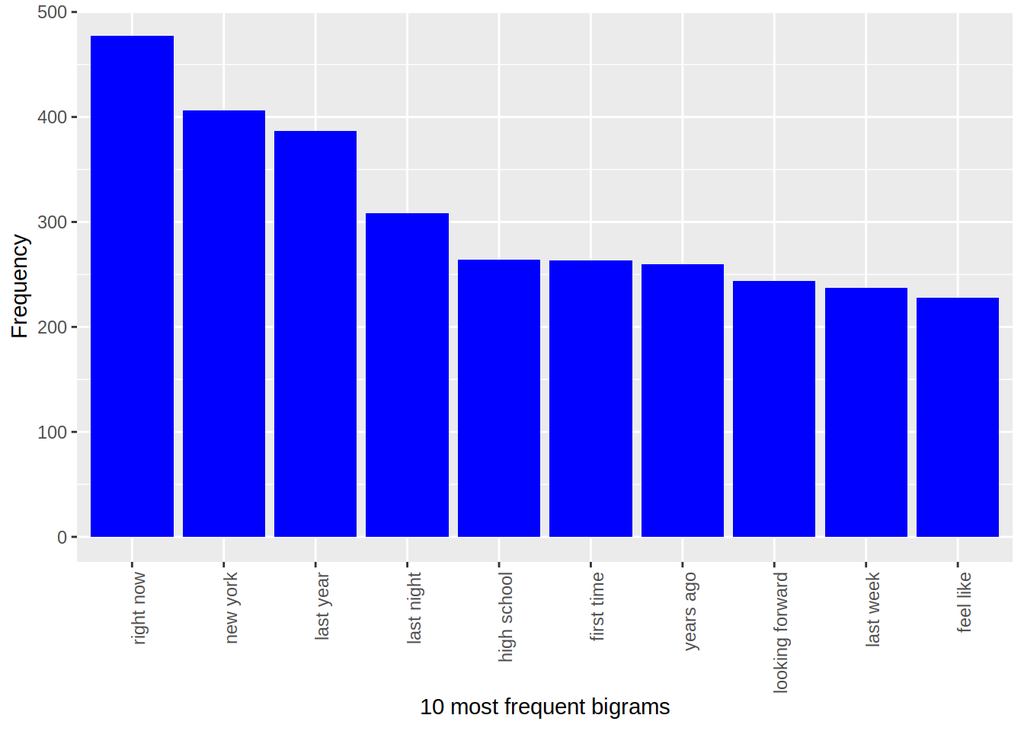

```r
freq2[1:10,] %>%
  ggplot(aes(reorder(word, -freq), freq)) +
         labs(x = "10 most frequent bigrams", y = "Frequency") +
         theme(axis.text.x = element_text(angle = 90, hjust = 1)) +
         geom_bar(stat = "identity", fill = I("blue"))
```

Plot of 10 most frequent trigrams

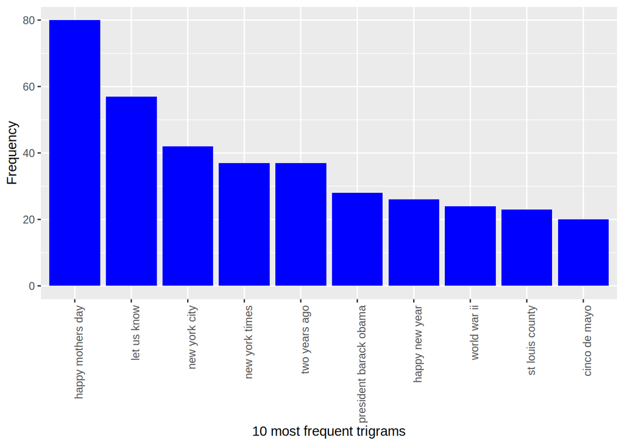

```r
freq3[1:10,] %>%
  ggplot(aes(reorder(word, -freq), freq)) +
         labs(x = "10 most frequent trigrams", y = "Frequency") +
         theme(axis.text.x = element_text(angle = 90, hjust = 1)) +
         geom_bar(stat = "identity", fill = I("blue"))
```

## Conclusion and Ideas por Final Capstone

We will use a ngram model in the final capstone project. We will take the trigram model first to predict next word, if we don’t have a matching trigram we’ll search for a bigram aplying the corresponding data model. We dismiss the quadgram model for not having significant information and the unigram because of memory allocation and speed. With these algorithm we are going to deploy our Shiny app.